# R/Python/Rust coding day

Shamit Soneji

2025-04-03

# Introduction

Many of us use a single language (usually R or Python) with rudimentary knowledge of a second. Moreover, most of us rarely use a compiled language such as C/C++/Rust which can be very useful to know if something needs to be done quickly. I’m guessing many use R a lot, but would like a better working knowledge of Python.

## So what’s the idea?

The idea is to have an away day for **capable** coders to program the same algorithm in three different languages, R, Python, and Rust. Rust has been gaining popularity at an impressive rate and has been used to create Cellranger and the Alevin-Fry suite, which is why we have chosen it here.

Each language will be led by a local expert (to be decided), but given Stefan is the only person who can code Rust (to the best of my knowledge) so he will lead this section. The theory is that by tackling the same problem three times, we should gain a better understanding of each language, as opposed to running through “Hello world” tutorials online that go at a glacial pace.

# The problem

The algorithm I have decided to use is the one given to my students on the R programming I course. It is clustering expression data using simulated annealing. It’s a simple algorithm to understand and program, but is has enough scope where solutions can vary widely. It also contains what most of what we need to know about a language, file reading, control flow, containers, maths, plotting etc.

**Each participant must have completed the problem in their language of choice to participate.**

## The data

For this problem we will use yeast cell-cycle data which is small timecourse dataset of 250 genes and 16 timepoints. You can get the data [here](https://github.com/shambam/R_programming_1/blob/main/Spellman_Yeast_Cell_Cycle.tsv). Yeast in liquid culture have been arrested at the same point in cell-cycle, and then released so they undergo two cell divisions in synchrony. They were sampled at 16 timepoints and then arrayed. This means there are some nice looking clusters in the data and will be clear if your implementation is working.

## Simulated annealing

We can think of well clustered data having low energy, in that each cluster is tight and has little within cluster variance. If we calculate the variance *within* each cluster and sum over all clusters we get the total variance (energy) of the system. To measure the distance between two genes $i$ and $j$ over $t$ timepoints we do:

$$d_{ij}=\sqrt{\sum{(g^{i}_t-g^{j}_t)^2}}$$

so to measure the energy (total variance) of a clustering we sum the pairwise distances for each cluster $K$, and then sum over all $K$s and them divide by $K$.

$$E(K)=\frac{1}{K}\sum^K_{k=1} \left[
\sum_{i\epsilon Ck}\sum_{j\epsilon Ck} d_{ij}\right]$$

For a well clustered data, $E(K)$ should be as **small** as possible. Lets say we have 1000 genes, and we want to partition them into 8 clusters. The number of combinations is too high for us to try each one to brute force a true $E$. This is why we use a *heuristic* algorithm to get us as close to the solution as possible in a smaller amount of time.

If we tried to visualise the energy landscape we can imagine it might look something like this:

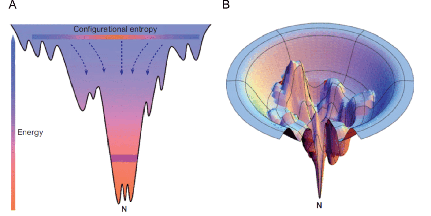

The idea behind simulated annealing is that “bad” moves are also allowed for a proportion of the iterations allowing exploration of the energy landscape, thereby avoiding local minima.

## The algorithm

Lets go through the process of the algorithm. To do this you need 4 parameters:

1. The temperature of the system $Temp$
2. Cooling factor $cool$
3. Number of clusters $K$
4. How many iterations to perform $I$.

Algorithm goes:

Randomly assign each gene to one of your K clusters.

for each iteration $I$ {

Calculate $E$. Call this $E_{old}$

Randomly select a single gene and assign it randomly to another cluster.

Calculate $E_{new}$

if($E_{new}$ < $E_{old}$) {accept the move}

if($E_{new} > E_{old})$ {if($e^{-\frac{E_{new}-E_{old}}{Temp}} > R(0,1)$) {accept the move} }

else{reject the move}

Set a new $Temp$ by doing $Temp=Temp \times cool$ }

Done

$R(0,1)$ is a randomly generated number from a uniform distribution that lies between 0 and 1.

## Things to do

1. Code this algorithm using the given yeast timecourse data.
2. Put this algorithm into a function that takes data, $Temp$, $cool$, $K$ and $I$ as arguments.
3. When running the function, make sure the starting $E_{start}$ and final $E_{final}$ are printed to the screen.
4. Plot the resulting clusters, something like:

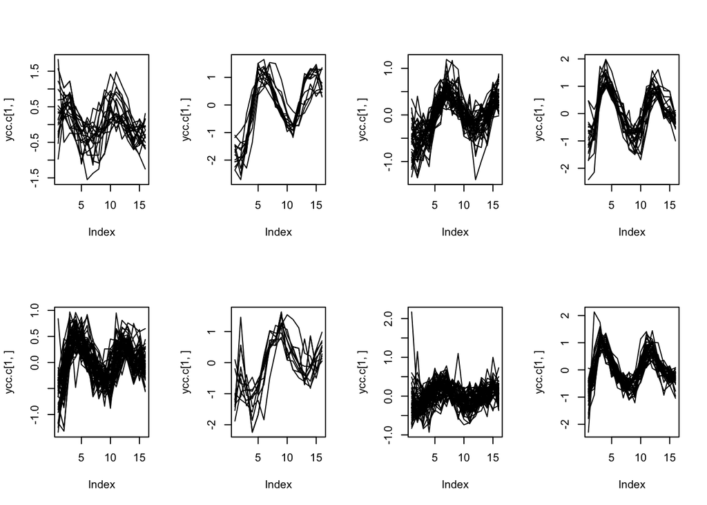

Or if you’re fancy:

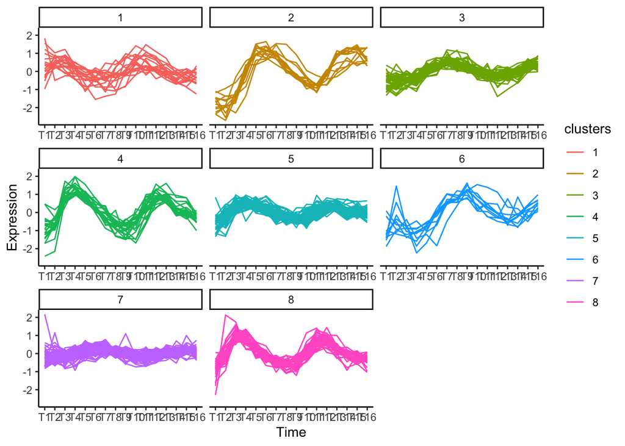

This problem should take around 2-3 hours to complete in R/Python **without ChatGPT**.